# SAD2

# Wstęp

Projekt dotyczy badania rynku gier komputerowych i mobilnych, czyli tematu, który nie jest często przytaczany. Rynek ten jest jednak bardzo ważny i warty uwagi, ze względu na jego ciągłe światowe wzrosty.

W tym projekcie, na podstawie danych z ankiety, związanych z rynkiem gier komputerowych, zostanie przeprowadzone badanie, jak bardzo podobne - bądź różne są preferencje kobiet i mężczyzn.

Przy pomocy metod uczenia maszynowego, zostaną wykonane próby klasyfikacji osób ze względu na płeć, opierając się na wartościach pozostałych zmiennych.

## Specyfikacja zbioru danych i wstępna analiza

Dane zostały zebrane samodzielnie i pochodzą z ankiety, dotyczącej wydatków na gry, opublikowanej na dwóch grupach internetowych: World of Warcraft Polska oraz Dota 2 Polska. Badaną populacją są zatem uczestnicy powyższych forów internetowych. W ankiecie znajdowało się 14 pytań mających na celu zebrać cechy charakteryzujące tą populację. Próbą, którą udało się uzyskać usuwając ze zbioru braki w danych, są odpowiedzi od 127 osób, które ze względu na losową technikę wyboru osób do ankiety, można uznać za próbę reprezentatywną badanej populacji. W wynikach ankiety zebrano następujące zmienne dyskretne:

- KM – zmienna informująca o płci w grupach: Kobieta, Mężczyzna,
- WIEK – zmienna informująca o wieku w postaci przedziałów, mniej niż 18 lat,od 18-tu do 25-ciu lat, od 25-ciu do 40-tu lat oraz więcej niż 40 lat,
- EDU – zmienna informująca o ostatnim ukończonym etapie edukacji, w kategoriach: szkoła podstawowa, szkoła średnia, studia licencjackie/inżynierskie, studia magisterskie oraz studia doktoranckie,
- STPR - Informacja o osobach uczących się i pracujących w postaci rozdziału na pracujących, uczących się oraz pracujących i jednocześnie uczących się,
- GRA – Informacja o gatunku gry, w który najczęściej gra badana osoba z podgrupami: MOBA, RPG, MMORPG, FPS, Battle royal oraz pozostałymi gatunkami,
- PCS – informacja o platformie, na której najczęściej grają badani w podziale na: komputer lub laptop, konsolę, oraz smartfon i tablet,

Poniżej mozna zobaczyć jak wyglądają odpowiedzi na pytania, i jak ilościowo rozkładają się wartości zmiennych.

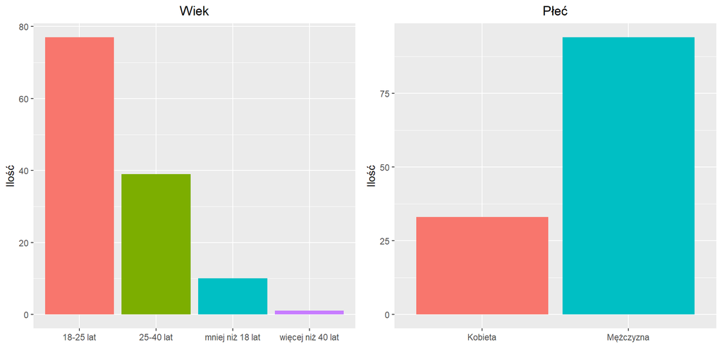

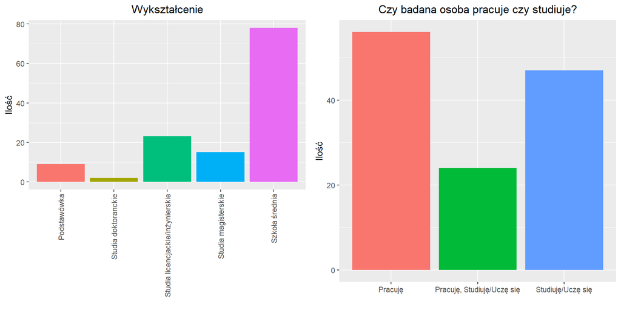

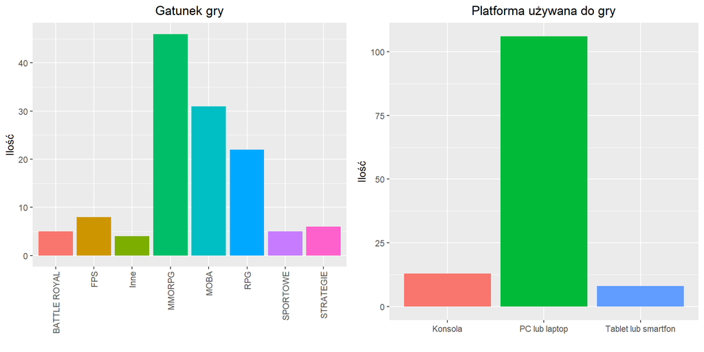

W ramach ankiety zebrano także zmienne, które można potraktować jako ciągłe ze względu na to, że mają ponad 10 możliwych odpowiedzi, można je przedstawić na skali ilościowej oraz przedstawienie ich w postaci ułamków ma sens – na przykład średni czas spędzany tygodniowo na graniu o wartości 20,5 godziny. Są to zmienne:

- CZAS – zmienna informująca o średnim tygodniowym czasie spędzonym na graniu wyrażonym w godzinach,
- DOCHOD – zmienna informująca o średnim dochodzie na osobę w gospodarstwie domowym wyrażonym w zł,
- WYDATKI – zmienna informująca o średnich rocznych wydatkach na gry wyrażonych w zł.

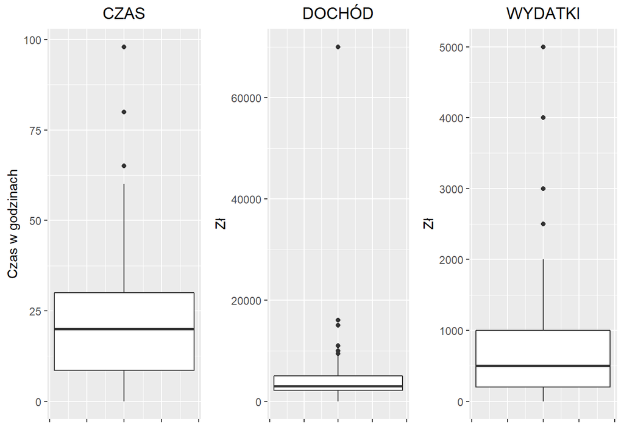

Na podstawie powyższych wykresów, można stwierdzić, że średni tygodniowy czas spędzony na graniu w gry, zawiera się w przedziale od 0 do 100. Średnio osoby badane grają mniej więcej 20 godzin tygodniowo.

Jeśli chodzi o dochód na głowę w gospodarstwie domowym, widać, że zaobserwowano tylko jeden wynik powyżej 20 000 zł, a średnio są to 3 - 4 tysiące zł.

Widać także, że wydatki roczne na gry zamykają się w przedziale 0 do 5000zł, a zdecydowana większość nie wydaje na gry więcej niż 2000 zł rocznie.

Poniżej można zobaczyć rozkłady, rozrzuty i histogramy zmienych CZAS, DOCHOD i WYDATKI.

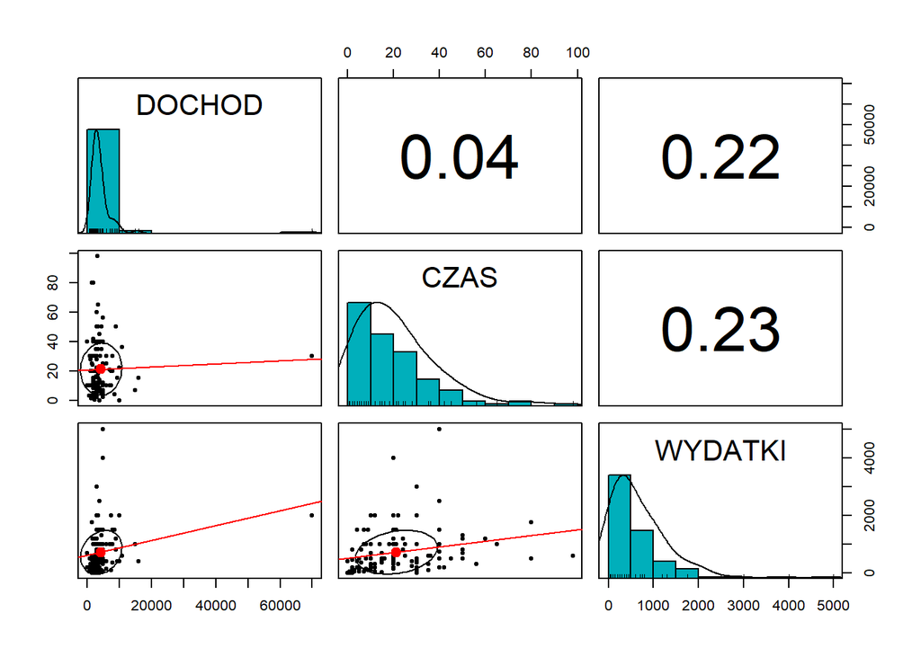

Na przekątnej rysunku, znajdują się histogramy zmiennych wraz z dopasowanymi funkcjami gęstości. Można na nich zobaczyć wspomniane wcześniej prawostronne skośności rozkładów zmiennych DOCHOD, CZAS i WYDATKI.

Pod przekątną, znajdują się wykresy rozrzutu zmiennych, z dopasowanymi liniami regresji. Można już teraz postawić hipotezę o tym, że spłaszczenie tych rozrzutów, na przykład dodając logarytmy zmiennych ciągłych, da nam lepsze wyniki w przypadku dopasowania modelu klasyczną metodą najmniejszych kwadratów oraz własności prognostycznych. W dodatku, przy założeniu, że zmienne mają dwuwymiarowy rozkład normalny, na wykresie zaznaczono także 95% elipsy ufności, oznaczające, że obserwacje z populacji będą znajdywać się w tym obszarze z prawdopodobieństwem 95%.

Nad przekątną, znajdują się współczynniki korelacji liniowej Pearsona między zmiennymi leżącymi na przecięciu rzędu i kolumny – to znaczy na przykład, że 0,23 jest współczynnikiem korelacji liniowej Pearsona dla zmiennych WYDATKI i CZAS, czyli zmienne są ze sobą słabo skorelowane. Z kolei prawie korelacji między zmiennymi DOCHOD I CZAS.

# Przygotowanie danych do badania

Przed przystąpieniem do badania, ze względun na używane w projekcie metody, należy odpowiednio przetransformować dane.

Zostały wykonane trzy transformacje wyjściowego zbioru danych, w następujący sposób:

- dane.liczbowe - dane, w których wartości kategoryczne zostały zamienione na liczbowe w sposób rosnący. Dla wartości porównywalnych jak wiek czy, wykształcenie, został przyjęcty schemat numerowania od 1, co 1 wzwyż, aż do maksymalnej wartości. W przypadku danych nieporównywalnych, jak GRA(gatunek gry), również został przyjęcty schemat numerowania od 1, co 1 wzwyż, gdzie najliczniejszy w odpowiedziach gatunek ma przypisany największy numer. Zmienne ciągłe pozostały bez zmian.
- dane.kategoryczne - dane, w których zmienne ciągłe zmieniono na przedziały.
- dane.binarne - dane, w których zmienne kategoryczne, zostały zamienione na odpowiadający im zbiór kilku zmiennych binarnych.

W dalszej części projektu, zostanie zbadane, czy sposób transformacji danych wpływa na osiągnięte wyniki, a jeśli wpływa to w jaki sposób.

# Przewidywanie płci na podstawie innych zmiennych

## Podział na zbiór testowy i uczący

Przed przystąpieniem do modelowania należy podzielić zbiór, na zbiór testowy oraz uczący. Ponieważ w badanym zbiorze jest 127 obserwacji, zdecydowano, że domyślnym podziałem, będzie podział taki, gdzie zbiór uczący zawiera 95 obserwacji, a zbiór testowy - 32.

Każdy ze zbiorów - dane liczbowe, kategoryczne i binarne, został podzielony w ten sam sposób, aby można było porównac ze sobą wyniki osiągane na tych zbiorach.

Poniżej przedstawiono wykresy, jak statystyki zmieniły się po podziale na zbiory uczące i testowe.

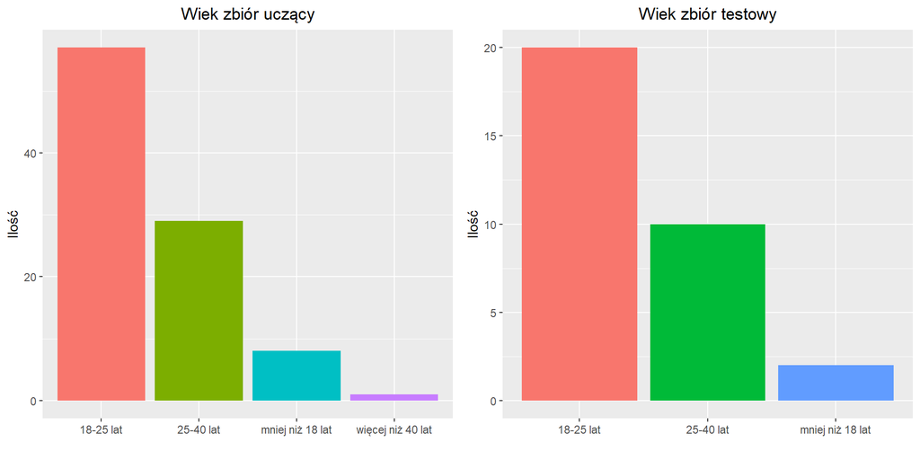

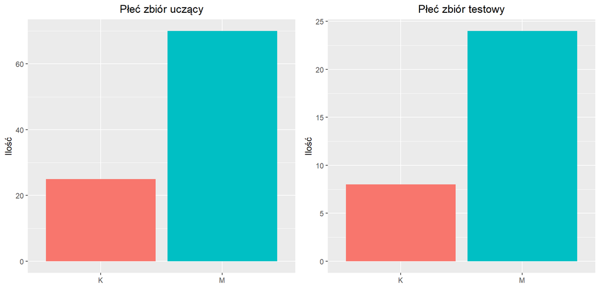

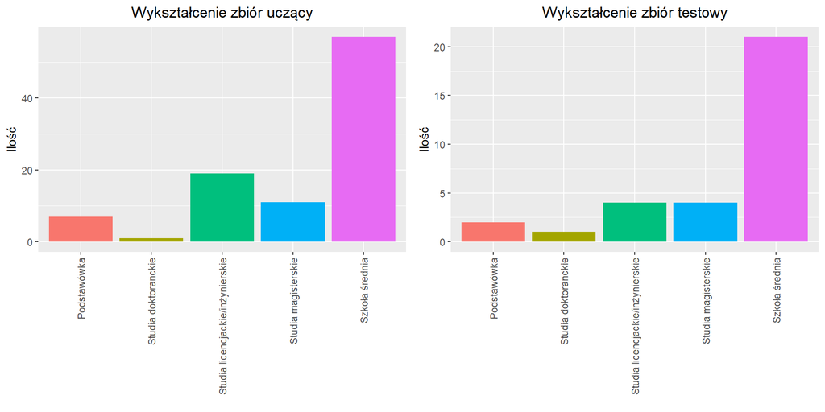

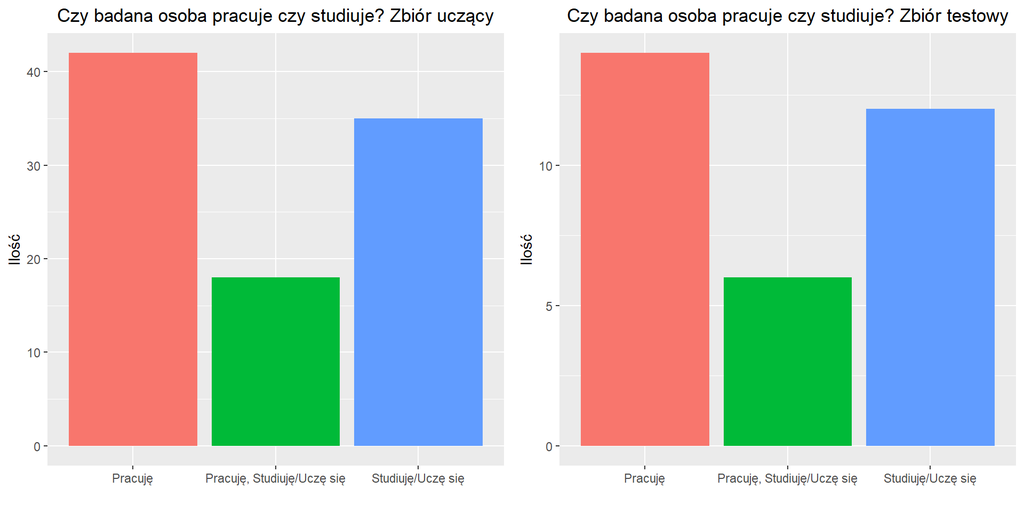

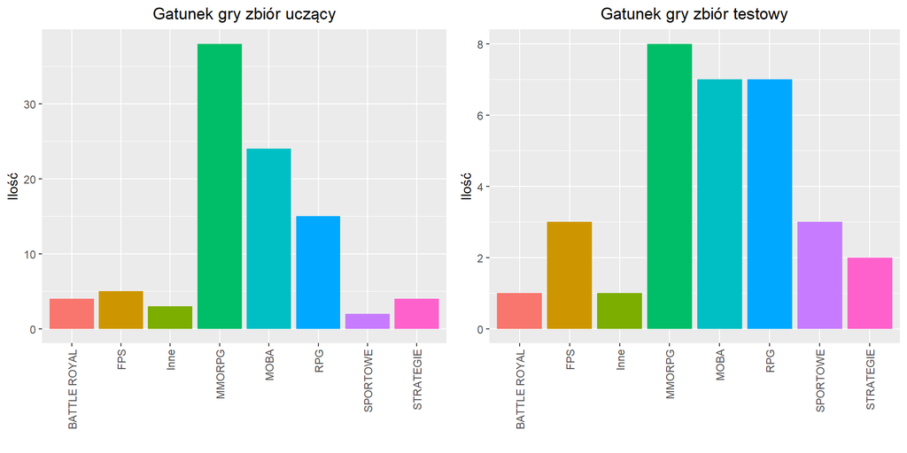

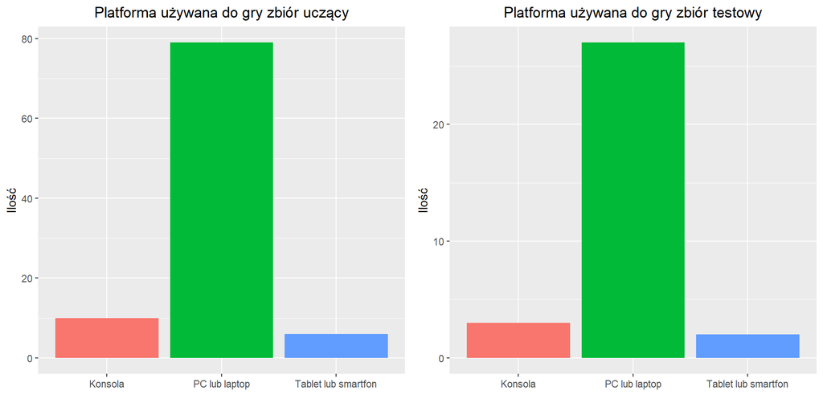

Dla danych kategorycznych nie widać większych zmian. Co do zasady próba ucząca i próba testowa są takie same. Wystepuja niewielkie róznice, pomiędzy stosunkiem odpowiedzi. Najbardziej zauważalnymi są różne rozłożenie wyników Gatunków gier, oraz wykształcenia, odpowiednio w zbiorach uczącym i testowym.

## Zbiór uczący:

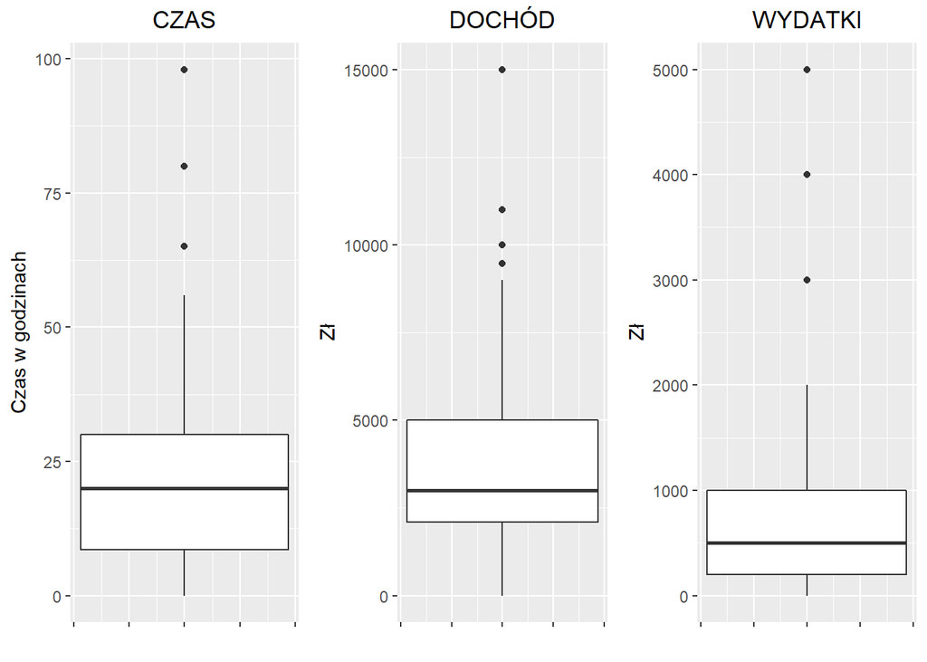

## Zbiór testowy:

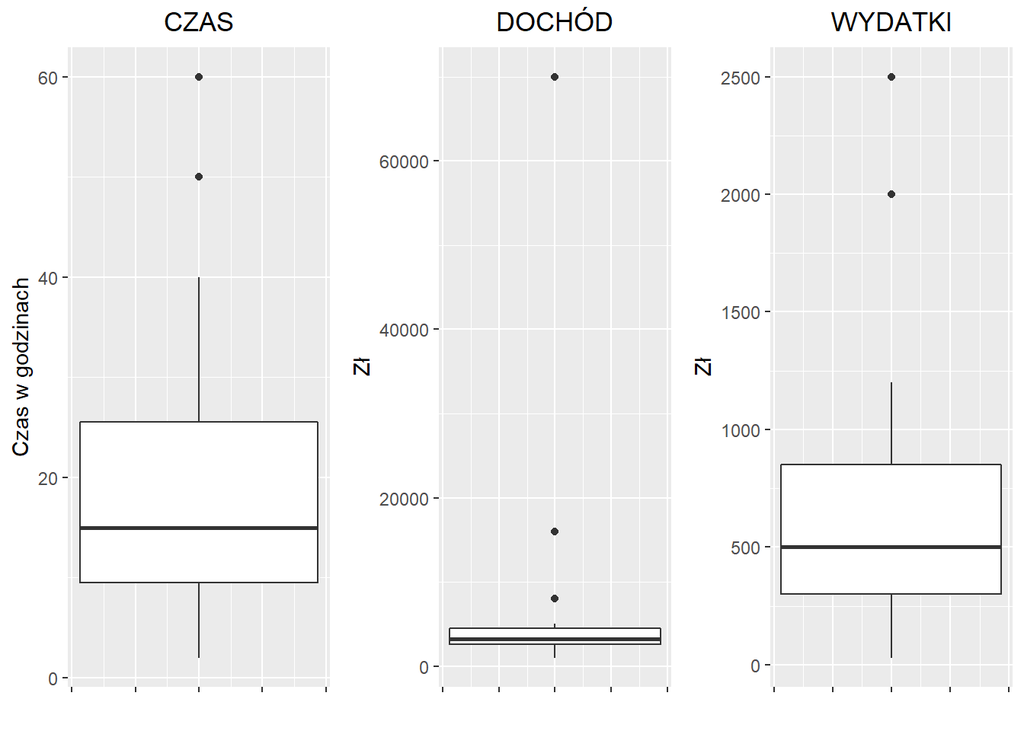

Widać, że dzięki przejściu obserwacji odstającego dochodu do grupy testowej, model ma szanse dobrze się dopasować do zbioru uczącego. Prawdopodobnie gdyby obserwacja odstająca dochodu - 70 000, została uwzględniona w danych uczących, modele mogłyby być mniej dokładne.

Statystyki dla zmiennych czas i wydatki pozostają względnie takie same międzygrupowo.

## Metoda najbliższych sąsiadów

Zaczynając klasyfikację płci na podstawie pozostałych zmiennych, skorzystano z metody k najbliższych sąsiadów. Przetestowane zostały modele dla danych liczbowych oraz binarnych.

Na poniższych wykresach mozna zobaczyć jak kształtowała się dokładność predykcji względem ilości wybieranych sąsiadów.

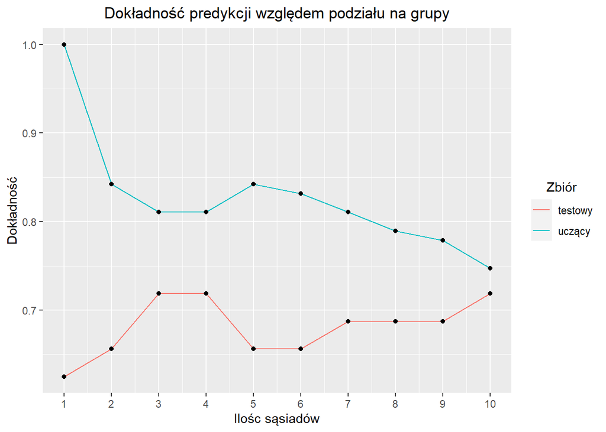

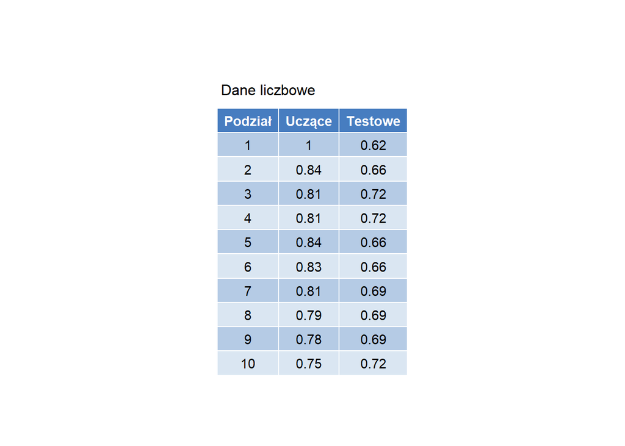

Poniżej natomiast, zaprezentowano jak zmiana postaci zmiennych na binarne wpłynie na dokładność predykcyjną modelu.

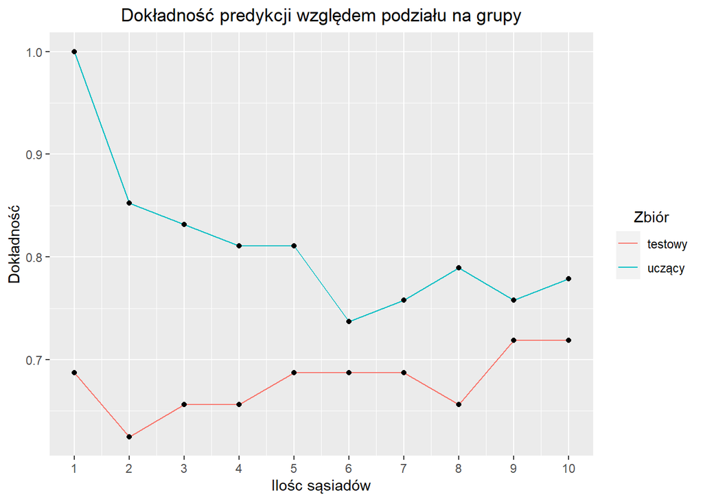

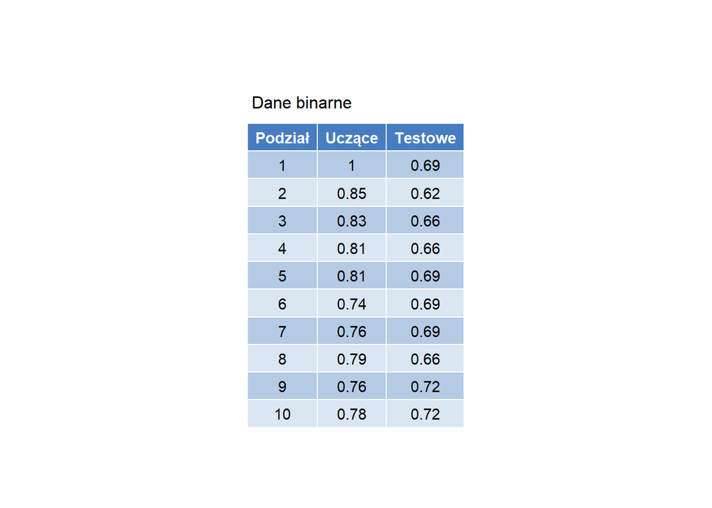

Pomimo, że predykcje nie wahają się bardzo przy zmianie ilości sąsiadów, to da się wyróżnić najlepsze wartości.

W dodatku można powiedzieć, że w przypadku metody k najbliższych sąsiadów, lepszym zbiorem okazał się zbiór danych liczbowych, gdyz dla niego uzyskano najlepszą średnią dokładność dla k=3.

Dokładność na zbiorze uczącym była równa 0.81, a na zbiorze testowym 0.72.

W przypadku nie uwzględniania dopasowania się modelu do danych uczących, wypadają one tak samo. Dla zbioru testowego, udało się poprawnie rozpoznać w 72% czy badana osoba jest mężczyzną czy kobietą.

## Klasyfikator naiwny Bayesa

Następną metodą jest klasyfikator naiwny Bayesa. Zbadano jaką dokładność predykcji można uzyskać używając każdego z 3 zbiorów danych.

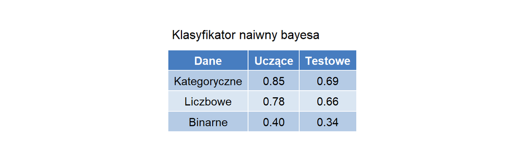

Co ciekawe klasyfikator Bayessa wydaje się o wiele gorzej działać dla zmiennych binarnych niż pozostałe metody. Zdecydowanie najlepsze dane to dane kategoryczne. Wynik taki był pożądany, ze względu na to, że w naiwnym klasyfikatorze Bayesa powinny być wykorzystywane własnie dane kategoryczne.

Ogólne dopasowanie do zbioru testowego jest słabsze niż w przypadku metody k najbliższych sąsiadów.

Metoda naiwnego klasyfikatora Bayessa poprawnie sklasyfikowała płeć 69% badanych osób ze zbioru testowego.

## Liniowa analiza dyskryminacji

Za pomocą liniowej analizy dyskryminacji, opierjącej się na maksymalizacji odleglosci między srednimi w grupach, przy jednoczesnej minimalizacji wewnątrzgrupowej wariancji, zostaną teraz wyznaczone predykcje dotyczące płci badanych osób.

W tej metodzie wykorzystane zostana dane binarne oraz liczbowe. Wyniki można zobaczyć w tabeli.

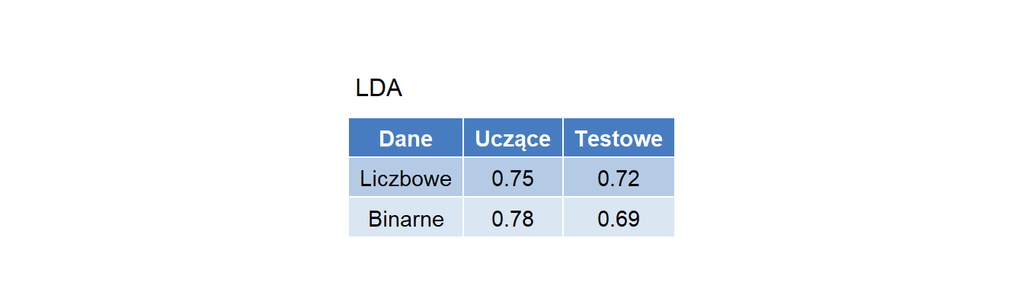

W przypadku LDA, dopasowanie do zbioru testowego nadal nie przekroczyło poziomu 72%, nie ma więc poprawy w stosunku do metody k najbliższych sąsiadów. Warto równiez zauważyć, że i w tej metodzie dane binarne dają mniejszą dokładność niż dane liczbowe.

## Regresja logistyczna

Ostatnią z testowanych metod predykcji, jest regresja logistyczna. W jej przypadku również wykorzystane zostaną dane binarne i liczbowe. Aby użyć regresji logistycznej jednak, trzeba najpierw zmienić wartości zmiennej KM z mężczyzny i kobiety (M lub K) na wartości liczbowe 0 i 1.

Regresja logistyczna dopasuje wtedy prawdopodobienstwo bycia przez daną osobę mężczyzną lub kobietą na podstawie wartości prawdopodobieństw zbliżonych do 0 lub 1.

Zdecydowaną wada tej metody, jest możliwość wykroczenia wartościami prawdopodobieństw poza zakres [0,1]. Można zobaczyć to na wykresie poniżej.

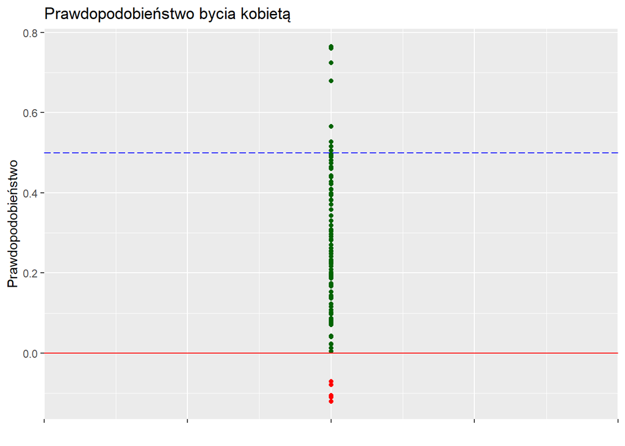

Wyniki dokładności predykcji można zobaczyć w poniższej tabeli

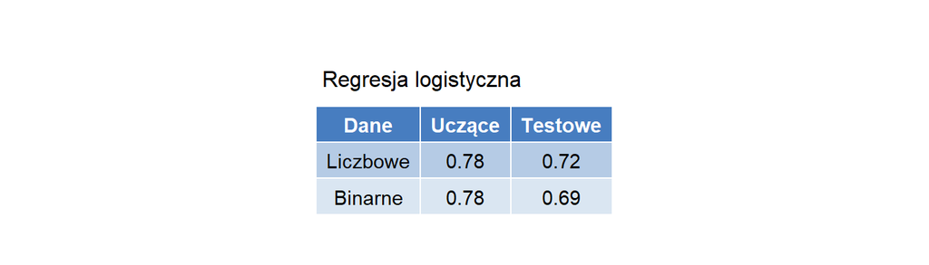

Regresja logistyczna również dała maksymalne dopasowanie predykcji równe 72%. A co za tym idzie, przy pomocy regresji logistycznej prawidłowo ze zbioru testowego udało sie poprawnie sklasyfikowac płeć 72% osób badanych.

# Podsumowanie

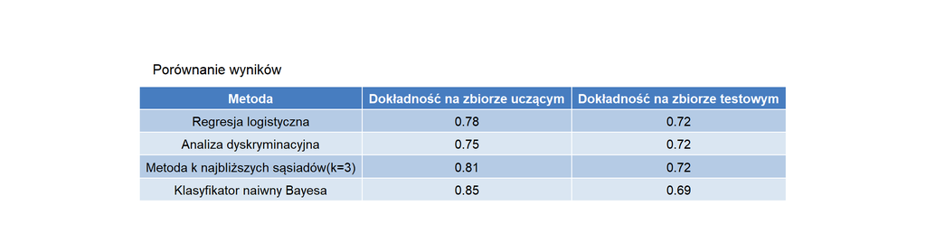

Należy także pamiętać, że w zbiorze testowym jest też jedna wartośc odstająca, Kobieta o wysokim dochodzie i wysokich dodatkach klasyfikowana jako mężczyzne przez wszystkie z modeli. Realnie więc dokładność na zbiorze testowym jest nieco wyższa.

Podsumowując, najlepszym uzyskanym wynikiem, jest dokładnośc rozpoznawanie płci badanych na poziomie 72%. Wynik ten daje o 22% większe szanse na prawidłowe rozpoznanie płci niż metoda losowa.